# Repetition analyses (N2)

Hannah, 6/19/2017

### 1. N2

“Current” trial will be included if:  
1) Current trial is not rejected due to artifacts.  
2) Current trial is not the first trial of the block (i.e. trial 1, 101, 201, 301 etc. are not included).  
3) Both current trial and previous trial are correct.

The following electrodes are included: F3, Fz, F4, FC3, FCz, FC4, C3, Cz, C4.

The following subjects were excluded: - 92 (wrong number of trials, possibly data collection error) - 64 (<50% accuracy rate) - 65 (only 187 usable trials (23.3%))

One or more electrodes were bad for subjects 19, 74, and 137 (data from those electrodes is discarded).

Besides that, ERP data is completely missing for subs 36, 37, 39, 40, 42, 43, 46, 51, 53, 54, 56, 57, 78.

**Total sample is 36 subjects.**

Trigger Codes: Comp: Target Left, Flanker Left = 110.  
Comp: Target Right, Flanker Right = 130.  
Incomp: Target Left, Flanker Right = 150.  
Incomp: Target Right, Flanker Left = 170.

CompleteRep (24.3%) = repetition of same trial (e.g., excludes 110 following 110)  
AnyRep (74.8%) = either target or flanker is repeated (only includes 110/130 pair, 150/170 pair)  
TargetRep (25.3%) = target is repeated (excludes 150/110 pair, 170/130 pair)  
FlankerRep (25.2%) = flanker is repeated (excludes 150/130 pair, 170/110 pair)

#### A. TargetRep trials taken out

##### Plot over whole task

**Slopes and estimates of lines are from the MLM, not fitted with OLS.**

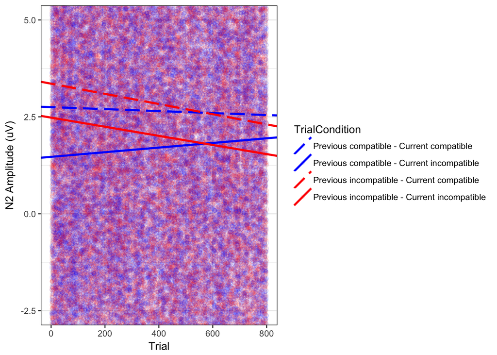

##### Simple slopes

Trial is scaled to range from 0 to 8 (instead of 1 to 800) so that the betas associated with trial are a little bigger (but significance testing is unaffected by linear scaling, so the test statistics and p values will be the same as if we used the unscaled Trial variable).

| Estimate | SE | ci95_lower | ci95_upper | Current | Previous | Color |
| --- | --- | --- | --- | --- | --- | --- |
| -0.0255 | 0.0172 | -0.05986 | 0.00887 | Compat | Compat | dashed blue |
| -0.1312 | 0.0254 | -0.18207 | -0.08041 | Compat | Incompat | dashed red |
| 0.0598 | 0.0257 | 0.00832 | 0.11118 | Incompat | Compat | solid blue |
| -0.1177 | 0.0187 | -0.15501 | -0.08030 | Incompat | Incompat | solid red |

##### Fixed effects of Trial and interactions with Trial:

Trial is centered and scaled to range from -4 to 4.

|  | Estimate | Std. Error | df | t value | Pr(>\|t\|) |
| --- | --- | --- | --- | --- | --- |
| Trial.begin | -0.054 | 0.011 | 153081.4 | -4.808 | 0.000 |
| Current:Trial.begin | 0.025 | 0.011 | 152304.9 | 2.216 | 0.027 |
| Previous:Trial.begin | -0.071 | 0.011 | 152159.8 | -6.345 | 0.000 |
| Current:Previous:Trial.begin | -0.018 | 0.011 | 152977.9 | -1.605 | 0.109 |

##### Fixed effects at beginning of task:

|  | Estimate | Std. Error | df | t value | Pr(>\|t\|) |
| --- | --- | --- | --- | --- | --- |
| (Intercept) | 2.513 | 0.452 | 35.662 | 5.557 | 0.000 |
| Current | -0.539 | 0.088 | 60.372 | -6.139 | 0.000 |
| Previous | 0.403 | 0.071 | 88.193 | 5.683 | 0.000 |
| Current:Previous | 0.101 | 0.078 | 73.047 | 1.308 | 0.195 |

**Marginal means:**  
Error bars represent standard error.

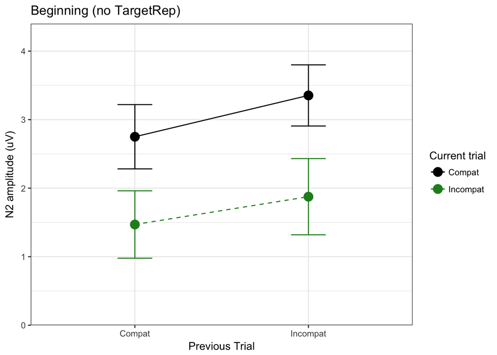

##### Fixed effects at middle of task:

|  | Estimate | Std. Error | df | t value | Pr(>\|t\|) |
| --- | --- | --- | --- | --- | --- |
| (Intercept) | 2.299 | 0.450 | 34.996 | 5.106 | 0.000 |
| Current | -0.440 | 0.076 | 34.421 | -5.768 | 0.000 |
| Previous | 0.120 | 0.056 | 34.398 | 2.137 | 0.040 |
| Current:Previous | 0.030 | 0.064 | 34.351 | 0.464 | 0.645 |

**Marginal means:**  
Error bars represent standard error.

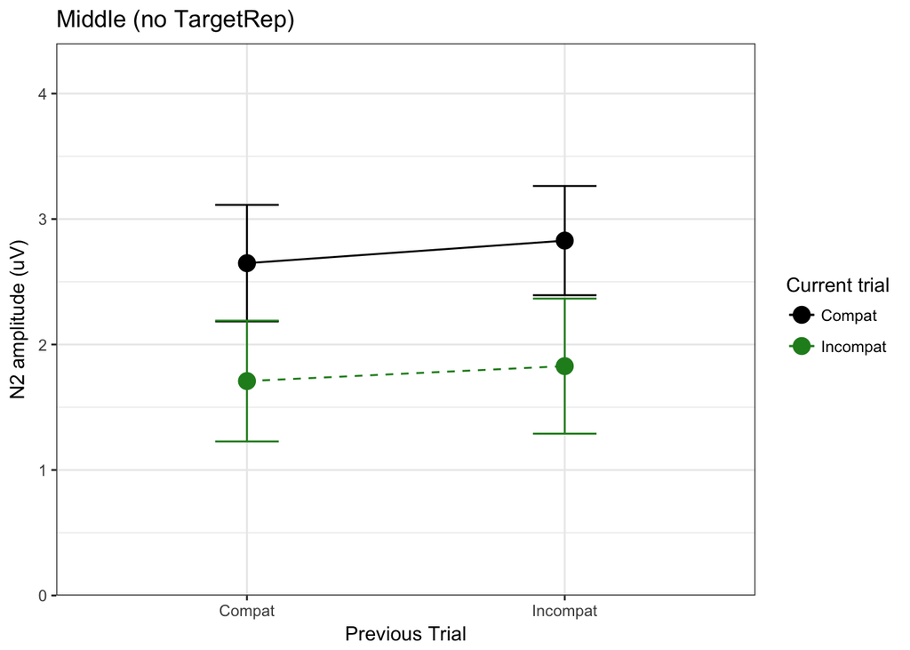

##### Fixed effects at end of task:

|  | Estimate | Std. Error | df | t value | Pr(>\|t\|) |
| --- | --- | --- | --- | --- | --- |
| (Intercept) | 2.084 | 0.452 | 35.727 | 4.606 | 0.000 |
| Current | -0.341 | 0.089 | 63.643 | -3.834 | 0.000 |
| Previous | -0.163 | 0.072 | 95.408 | -2.259 | 0.026 |
| Current:Previous | -0.042 | 0.079 | 78.089 | -0.531 | 0.597 |

**Marginal means:**  
Error bars represent standard error.

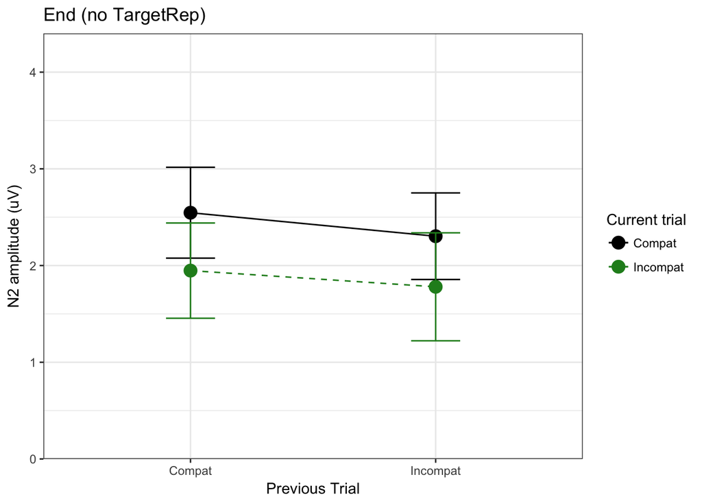

#### B. CompleteRep trials taken out